# MDS_dataset

AllenY

5/5/2020

## Question to answer:

Please show the loss of the yields depending on the planting date in the 4 maturity groups (Early4, Medium 4, Late 4, and Early 5).  
Also if you notice anything else about the data that you feel should be analyzed and reported, please do so.

```r
library(ggplot2)
library(tidyr)
library(reshape2)
library(ggpubr)
library(dplyr)
library(tidyverse)
library(tidyr)
library(gplots)
```

```r
# read in files
mds <- read.csv('MDS.csv', header = T)
mds_full <- mds
colnames(mds)[2] <- c('days')
head(mds)
```

```
##        date days RM.E4 RM.E5 RM.L4 RM.M4
## 1  2019/5/2    1 102.9 101.0 108.6 107.5
## 2  2019/5/6    5  66.3  68.2  70.2  70.8
## 3  2019/5/8    7  78.3  76.1  83.3  80.6
## 4 2019/5/10    9  76.9  78.8  86.1  84.0
## 5 2019/4/30   -1  74.2  81.7  85.7  85.4
## 6 2019/5/15   14  86.5  92.8  93.8  95.4
```

### Create heatmap in R (Same as the graph in excel)

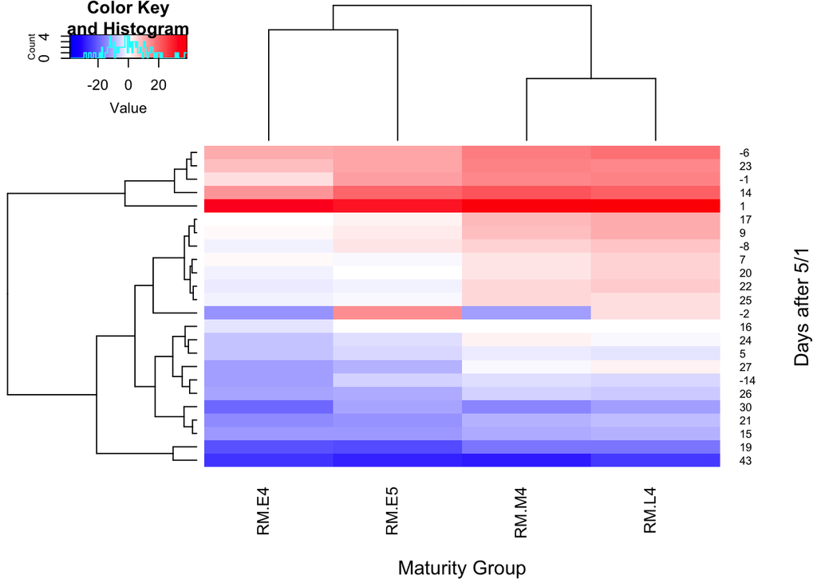

```r
hm <- as.matrix(mds[,c(3:6)])
rownames(hm) <- mds$days
hm_dev <- hm - colMeans(hm)
heatmap.2(hm_dev, scale = 'none', col = bluered(100), trace = 'none',
          cexRow = 0.7, cexCol = 1, lhei = c(0.5,1.5), lwid = c(0.5,1.5),
          margins = c(6,5), keysize = 2, xlab = 'Maturity Group',
          ylab = 'Days after 5/1')
```

Each column represents the yield for each plating date for each maturity group.  
Increase in red means the yield is higher than the Maturity Group’s average. Increase in blue means the yield is lower than the Maturity Group’s average.  
This graph tells us what dates to plant would have higher yield and what dates to plant would have lower yield.

```r
# long format
mds_gather <- gather(mds, key = 'rm', value = 'yield', 3:6, factor_key = T)
mds_gather$date <- as.Date(mds_gather$date)
head(mds_gather)
```

```
##         date days    rm yield
## 1 2019-05-02    1 RM.E4 102.9
## 2 2019-05-06    5 RM.E4  66.3
## 3 2019-05-08    7 RM.E4  78.3
## 4 2019-05-10    9 RM.E4  76.9
## 5 2019-04-30   -1 RM.E4  74.2
## 6 2019-05-15   14 RM.E4  86.5
```

### Create new variable: day_range

Since the information I have on the time variable wasn’t sufficient enough to perform proper statistical analysis, I created a new time variable “day_range”- bins to group similar dates.

weeks_prior: planting date was at least 7 days earlier than 5/1  
peak_week: planting date was between 7 days prior than 5/1 or 7 days after 5/1  
1_week_late: planting date was between 7 days and 15 days after 5/1  
2_week_late: planting date was between 15 days and 22 days after 5/1  
weeks_late: planting date was at least 22 days later than 5/1

```r
# create bins for planting date
mds_gather <- mds_gather %>%
  mutate(day_range = case_when(days < -7 ~ 'weeks_prior',
                               days >= -7 & days < 7 ~ 'peak_week',
                               days >= 7 & days < 15 ~'1_week_late',
                               days >=15 & days < 22 ~ '2_weeks_late',
                               days >=22 ~ 'weeks_late'))
mds_gather$day_range <- as.factor(mds_gather$day_range)
mds_gather$day_range <- factor(mds_gather$day_range,
                               levels = c('weeks_prior','peak_week','1_week_late','2_weeks_late', 'weeks_late'))
head(mds_gather)
```

```
##         date days    rm yield   day_range
## 1 2019-05-02    1 RM.E4 102.9   peak_week
## 2 2019-05-06    5 RM.E4  66.3   peak_week
## 3 2019-05-08    7 RM.E4  78.3 1_week_late
## 4 2019-05-10    9 RM.E4  76.9 1_week_late
## 5 2019-04-30   -1 RM.E4  74.2   peak_week
## 6 2019-05-15   14 RM.E4  86.5 1_week_late
```

### ANOVA for variable rm and day_range

```r
# anova rm and day_range
aov.rm_dr <- aov(yield ~ rm*day_range, data = mds_gather)
summary(aov.rm_dr)
```

```
##              Df Sum Sq Mean Sq F value   Pr(>F)
## rm            3    729   242.8   1.623    0.191
## day_range     4   4898  1224.6   8.185 1.52e-05 ***
## rm:day_range 12     93     7.7   0.052    1.000
## Residuals    76  11371   149.6
## ---
## Signif. codes:  0 '***' 0.001 '**' 0.01 '*' 0.05 '.' 0.1 ' ' 1
```

Since day_range is significant, we can single out each day_range and find the best rm within.

### ANOVA for Maturity Group in day_range: weeks_prior

```r
# weeks_prior
wp <- mds_gather[mds_gather[,'day_range']=='weeks_prior', ]

aov_wp <- aov(yield ~ rm, data = wp)
summary(aov_wp)
```

```
##             Df Sum Sq Mean Sq F value Pr(>F)
## rm           3  84.31   28.10     0.4  0.761
## Residuals    4 281.11   70.28
```

Maturity group’s effect was not significant in this case, meaning there is no significant differences in yield loss between different mature group.

### ANOVA for Maturity Group in day_range: peak_week

```r
# peak_week
pw <- mds_gather[mds_gather[,'day_range']=='peak_week', ]

aov_pw <- aov(yield ~ rm, data = pw)
summary(aov_pw)
```

```
##             Df Sum Sq Mean Sq F value Pr(>F)
## rm           3    242   80.68   0.369  0.776
## Residuals   16   3494  218.39
```

Maturity group’s effect was not significant in this case as well, meaning there is no significant differences in yield loss between different mature group.

### ANOVA for Maturity Group in day_range: 1_week_late

```r
wl1 <- mds_gather[mds_gather[,'day_range']=='1_week_late', ]

aov_wl1 <- aov(yield ~ rm, data = wl1)
summary(aov_wl1)
```

```
##             Df Sum Sq Mean Sq F value Pr(>F)
## rm           3  102.9   34.30   0.697   0.58
## Residuals    8  393.8   49.23
```

Maturity group’s effect was not significant in this case as well, meaning there is no significant differences in yield loss between different mature group.

### ANOVA for Maturity Group in day_range: 2_weeks_late

```r
# 2_weeks_late
wl2 <- mds_gather[mds_gather[,'day_range']=='2_weeks_late', ]

aov_wl2 <- aov(yield ~ rm, data = wl2)
summary(aov_wl2)
```

```
##             Df Sum Sq Mean Sq F value Pr(>F)
## rm           3  129.2   43.06    0.42  0.741
## Residuals   20 2049.8  102.49
```

Maturity group’s effect was not significant in this case as well, meaning there is no significant differences in yield loss between different mature group.

### ANOVA for Maturity Group in day_range: weeks_late

```r
# weeks_late
wls <- mds_gather[mds_gather[,'day_range']=='weeks_late', ]

aov_wls <- aov(yield ~ rm, data = wls)
summary(aov_wls)
```

```
##             Df Sum Sq Mean Sq F value Pr(>F)
## rm           3    263   87.61   0.476  0.701
## Residuals   28   5152  184.01
```

Maturity group’s effect was not significant in this case as well, meaning there is no significant differences in yield loss between different mature group.

### Plot each Maturity group’s daily yield against planting day

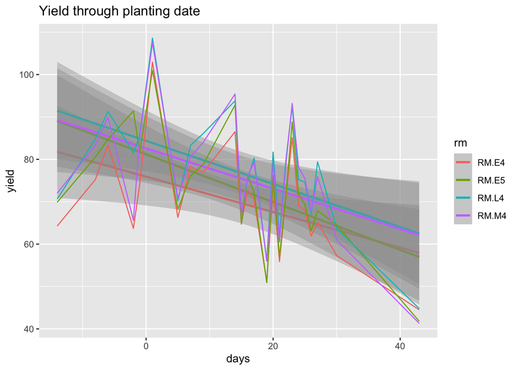

```r
ggplot(data = mds_gather, aes(x=days, y=yield, color = rm))+
  geom_smooth(method='lm')+
  geom_line()+
  labs(title='Yield through planting date')
```

The straight lines are the regression lines for each mature group.  
According to this dataset, the loss of yield would increase through time.

### Best day_range to plant

Since we know day_range effect is sigificant, we can find out which day_range would be the best and worst in yield.

```r
aov_dr <- aov(yield ~ day_range, data = mds_gather)
tk_dr <- TukeyHSD(aov_dr)
tk_dr
```

```
##   Tukey multiple comparisons of means
##     95% family-wise confidence level
##
## Fit: aov(formula = yield ~ day_range, data = mds_gather)
##
## $day_range
##                                 diff        lwr       upr     p adj
## peak_week-weeks_prior      8.6350000  -4.841929 22.111929 0.3895744
## 1_week_late-weeks_prior    9.3183333  -5.386202 24.022869 0.4009742
## 2_weeks_late-weeks_prior  -7.2608333 -20.412969  5.891303 0.5417235
## weeks_late-weeks_prior    -6.0525000 -18.787001  6.682001 0.6778022
## 1_week_late-peak_week      0.6833333 -11.080295 12.446962 0.9998438
## 2_weeks_late-peak_week   -15.8958333 -25.649719 -6.141948 0.0001671
## weeks_late-peak_week     -14.6875000 -23.870479 -5.504521 0.0002300
## 2_weeks_late-1_week_late -16.5791667 -27.969251 -5.189083 0.0009951
## weeks_late-1_week_late   -15.3708333 -26.276009 -4.465658 0.0015590
## weeks_late-2_weeks_late    1.2083333  -7.490987  9.907654 0.9951892
```

### Boxplot for each day_range

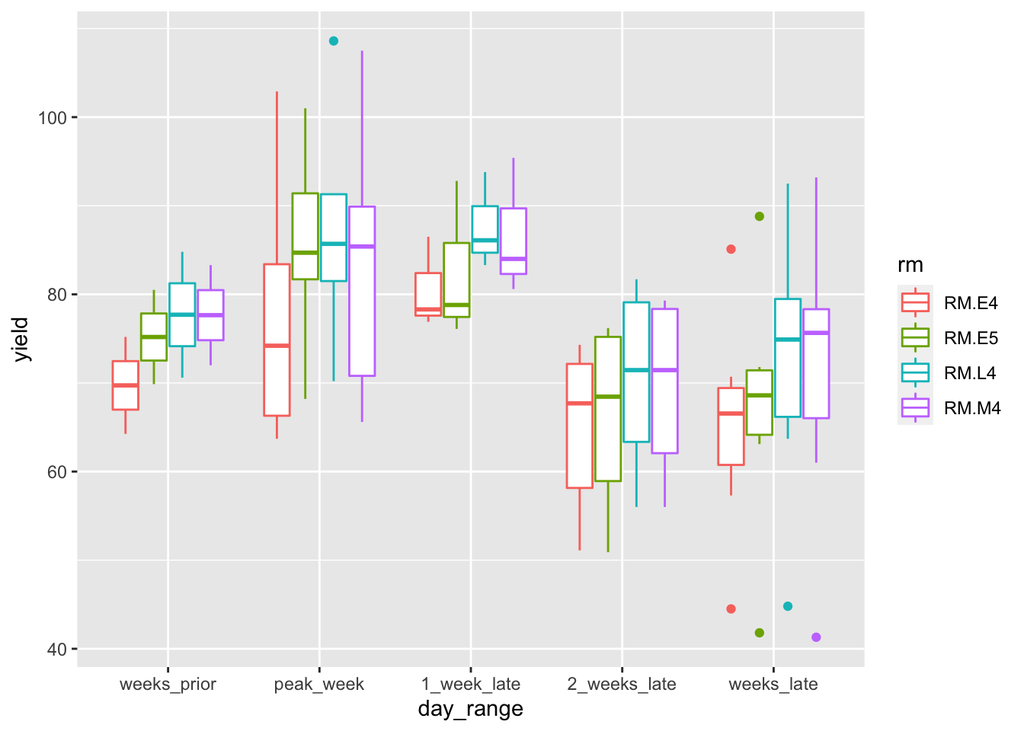

```r
# boxplot
ggplot(data = mds_gather, aes(x=day_range, y=yield, color=rm))+
  geom_boxplot()
```